# HW07 Data Importing and Wrangling

William Zoughaib

19 July 2020

```r
install.packages("here")
```

```r
library(ggplot2)
```

```r
library(tidyverse)
library(here)
```

```r
library(ggplot2)
```

###Assignment 1: **Limpets**

```r
limpets_data <- read_csv(here("data","limpets.csv"),col_types="ncc")
```

```r
limpets_data
```

| Length | Site | Protected |
| --- | --- | --- |
| 10 | PBL | Yes |
| 10 | PBL | Yes |
| 10 | PBL | Yes |
| 15 | PBL | Yes |
| 15 | PBL | Yes |
| 15 | PBL | Yes |
| 15 | PBL | Yes |
| 15 | PBL | Yes |
| 15 | PBL | Yes |
| 15 | PBL | Yes |

[output cut: 990 more lines]

####Are the data tidy?

```r
as_tibble(limpets_data)
```

| Length | Site | Protected |
| --- | --- | --- |
| 10 | PBL | Yes |
| 10 | PBL | Yes |
| 10 | PBL | Yes |
| 15 | PBL | Yes |
| 15 | PBL | Yes |
| 15 | PBL | Yes |
| 15 | PBL | Yes |
| 15 | PBL | Yes |
| 15 | PBL | Yes |
| 15 | PBL | Yes |

[output cut: 990 more lines]

```r
# tidying the data
# data is the same as previous code chunk so data is tidy
```

####Set col_types argument to numeric,character,and character

```r
# col_types have already been set to numeric, character,character
```

####Make sites column an ordered factor

```r
?factor
```

```r
limpets_data$Site <- factor(limpets_data$Site,levels=c("PBL","KNRM","VBG","WP","PF","DP","SIO","CTZ1","CTZ2","CNM"),ordered=TRUE)
```

```r
limpets_data
```

| Length | Site | Protected |
| --- | --- | --- |
| 10 | PBL | Yes |
| 10 | PBL | Yes |
| 10 | PBL | Yes |
| 15 | PBL | Yes |
| 15 | PBL | Yes |
| 15 | PBL | Yes |
| 15 | PBL | Yes |
| 15 | PBL | Yes |
| 15 | PBL | Yes |
| 15 | PBL | Yes |

[output cut: 990 more lines]

####Create a boxplot for limpets data

```r
?labs
```

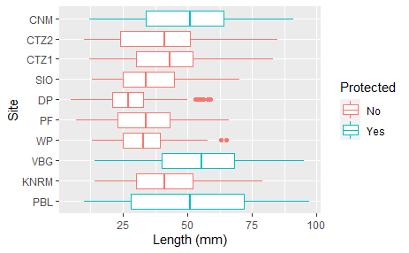

```r
ggplot(data=limpets_data)+
  geom_boxplot(mapping=aes(x=Length,y=Site,color=Protected))+labs(x="Length (mm)")+
  labs()
```

#### DP and WP are the only two boxplots with outliers. It can be observed that protected sites have larger limpets that unprotected sites.

###Assignment 2: **Roseate Terns**

```r
library("tidyverse")
```

```r
?read_tsv
```

```r
terns_data <- read_tsv(here("data","roseate_terns.txt"))
# using read_tsv instead of read_csv
```

```r
terns_data
```

| year | AR | AL | AC | BR | BL | BC | JR | JL | JC |
| --- | --- | --- | --- | --- | --- | --- | --- | --- | --- |
| 1992 | 378 | 76 | 29 | 378 | NA | 29 | 651 | NA | 35 |
| 1993 | 427 | 76 | 28 | 427 | 76 | 28 | 717 | 50 | 30 |
| 1994 | 394 | 140 | 35 | 394 | NA | 35 | 553 | NA | 35 |
| 1995 | 554 | 62 | 36 | 554 | 62 | 36 | 697 | 96 | 36 |
| 1996 | 563 | 124 | 24 | 563 | 124 | 24 | 770 | 106 | 24 |
| 1997 | 602 | 48 | 25 | 34 | 48 | 25 | 35 | 52 | 17 |
| 1998 | 578 | 80 | 29 | 79 | 9 | 29 | 69 | 13 | 33 |
| 1999 | 611 | 116 | 34 | 125 | 14 | 34 | 161 | 20 | 33 |
| 2000 | 618 | NA | 34 | 174 | NA | 34 | 265 | NA | 33 |
| 2001 | 605 | 46 | 42 | 80 | 46 | 42 | 118 | 0 | 55 |

[output cut: 15 more lines]

####Tidy the data

```r
tidy_terns <- terns_data %>% pivot_longer(c(AR:JC),names_to="Site",values_to="Population")
# remember to use the %>% function as it is very very useful.  Also, syntactic words do not get ` `.
```

| year | Site | Population |
| --- | --- | --- |
| 1992 | AR | 378 |
| 1992 | AL | 76 |
| 1992 | AC | 29 |
| 1992 | BR | 378 |
| 1992 | BL | NA |
| 1992 | BC | 29 |
| 1992 | JR | 651 |
| 1992 | JL | NA |
| 1992 | JC | 35 |
| 1993 | AR | 427 |

[output cut: 215 more lines]

####Filter out missing Counts

```r
?filter
```

```r
terns_filtered <- filter(drop_na(tidy_terns))
```

```r
terns_filtered
```

| year | Site | Population |
| --- | --- | --- |
| 1992 | AR | 378 |
| 1992 | AL | 76 |
| 1992 | AC | 29 |
| 1992 | BR | 378 |
| 1992 | BC | 29 |
| 1992 | JR | 651 |
| 1992 | JC | 35 |
| 1993 | AR | 427 |
| 1993 | AL | 76 |
| 1993 | AC | 28 |

[output cut: 204 more lines]

####Create a Line Plot of population size over time

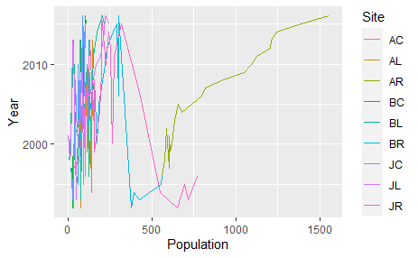

```r
ggplot(data=terns_filtered)+
  geom_line(mapping=aes(x=Population,y=year,color=Site))+
  labs(y="Year")
```

###Assignment 3: Blacklip Abalone #### Chunk 1: import abolone data, remove first column, and make a boxplot of height differences

```r
abalone_data <- read_csv(here("data","abalone.csv"))
select(abalone_data,-(X1))
```

| Type | LongestShell | Diameter | Height | WholeWeight | ShuckedWeight | VisceraWeight | ShellWeight | Rings |
| --- | --- | --- | --- | --- | --- | --- | --- | --- |
| M | 0.455 | 0.365 | 0.095 | 0.5140 | 0.2245 | 0.1010 | 0.1500 | 15 |
| M | 0.350 | 0.265 | 0.090 | 0.2255 | 0.0995 | 0.0485 | 0.0700 | 7 |
| F | 0.530 | 0.420 | 0.135 | 0.6770 | 0.2565 | 0.1415 | 0.2100 | 9 |
| M | 0.440 | 0.365 | 0.125 | 0.5160 | 0.2155 | 0.1140 | 0.1550 | 10 |
| I | 0.330 | 0.255 | 0.080 | 0.2050 | 0.0895 | 0.0395 | 0.0550 | 7 |
| I | 0.425 | 0.300 | 0.095 | 0.3515 | 0.1410 | 0.0775 | 0.1200 | 8 |
| F | 0.530 | 0.415 | 0.150 | 0.7775 | 0.2370 | 0.1415 | 0.3300 | 20 |
| F | 0.545 | 0.425 | 0.125 | 0.7680 | 0.2940 | 0.1495 | 0.2600 | 16 |
| M | 0.475 | 0.370 | 0.125 | 0.5095 | 0.2165 | 0.1125 | 0.1650 | 9 |
| F | 0.550 | 0.440 | 0.150 | 0.8945 | 0.3145 | 0.1510 | 0.3200 | 19 |

[output cut: 990 more lines]

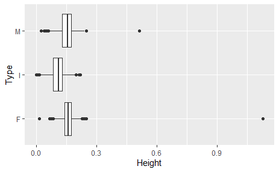

```r
ggplot(data=abalone_data)+
  geom_boxplot(mapping=aes(x=Height,y=Type))
```

```r
# using read_csv, then selecting against X1 column, then creating a boxplot by using Height v Type (originally used height v type)
```

#### Chunk 2: create a scatterplot to see if height correlates with rings

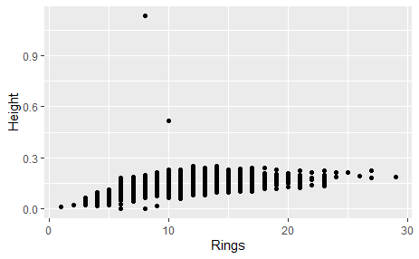

```r
ggplot(data=abalone_data)+
  geom_point(mapping=aes(x=Rings,y=Height))
```

#### Chunk 3: Filter out the outliers. Remove the two large indivuals. Change Type to an ordered factor. Immatures are first. Redo the scatterplot

```r
abalone_clean <- filter(abalone_data,Height<=0.4)
factor(abalone_clean$Type,levels=c('I','F','M'))
```

```
   [1] M M F M I I F F M F F M M F F M I F M M M I F F
  [25] F F F M M M M F M F F M F F F M F F I I I I M F
  [49] I F I M M F M F M M I F M M F M M M F F F I M F
  [73] F M F F M F F F F M F M M F M M F F M M M F M M
  [97] M M M F I M M M M F F F F F M M I M F F F M F M
 [121] F I F M I I I I M M M F F I I F F M F M F F M M
 [145] M F M I I I M F F F F M F M F F M F M F F M F F
 [169] M F M F M F I I I I I M M M F F F M F F F F M M
 [193] M I F M F M M M F M F F M F I I F I F M F M F M
 [217] M I M F F F F F I F F I F F M M M I I I I I I I
 [241] M I I I I I I I I I I M F F M M M M F F F F M I
 [265] M F M M M F F M M M M M F M M F F I F M M F M F
 [289] M F M F M F M I I I M M F F M M F I I M M M F M
 [313] M F M I F M F I I I M I M I I M M I M F I I F M
 [337] M M M F M F M F F M F I I M F F M M M M M F M F
```

[output cut: 29 more lines]

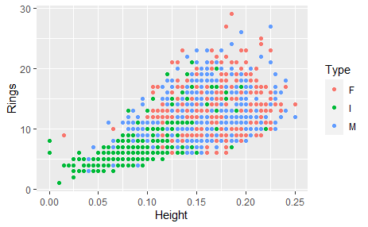

```r
ggplot(data=abalone_clean)+
  geom_point(mapping=aes(x=Height,y=Rings,color=Type))
```

#### Chunk 4: Select the individuals with zero height and assign them an NA value. Redo scatterplot

```r
abalone_clean[abalone_clean$Height == 0, 'Height']
ggplot(data=abalone_clean)+
  geom_point(mapping = aes(x=Height,y=Rings,color=Type))
# I think this is the correct way
```

[output not shown]

```r
is.na <- filter(abalone_data,Height==0)
ggplot(data=abalone_clean)+
  geom_point(mapping=aes(x=Height,y=Rings,color=Type))
# this is the same scatterplot as above except that I filtered it out.
```

[output not shown]

#### Chunk 5: Create two different scatterplots of continuous variables. Use color and/or shape.

[output not shown]

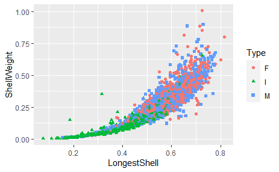

```r
ggplot(data=abalone_clean)+
  geom_point(mapping=aes(x=LongestShell,y=ShellWeight,color=Type,shape=Type))
```

#### In here we have a curve in the data. Immatures will have the lower ShellWeight v. LongestShell versus their Female and Male counterparts.

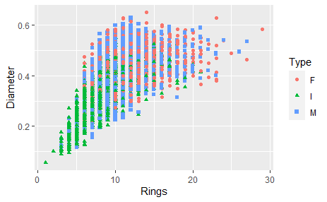

```r
ggplot(data=abalone_clean)+
  geom_point(mapping=aes(x=Rings,y=Diameter,color=Type,shape=Type))
```

####Interestingly, Diameter is greatest for male and female at around 10-12 rings. Then there is a slight decrease in diameter as rings are added. Again immatures will have a smaller ratio of Rings to Diameter than the adult counterparts.

###Assignment 4: Darters

```r
?read_fwf
```

```r
library(tidyverse)
```

####Load darters data. Assign Column names. Make Riffle an unordered factor while Maj_Type is an ordered factor

```r
darters_data <- read_fwf(here("data", "darter.txt"), fwf_widths(c(3, 11, 1, 1, 1, 3, 4, 4, 4, 3, 3, 2, 2)), comment = '#')
darters_named <- darters_data %>% rename(ID=X1,Species=X2,Riffle=X3,Age=X4,Sex=X5,Length=X6,Depth=X7,Velocity=X8,Temperature=X9,Maj_Sub=X10,Min_Sub=X11,Maj_Type=X12,Min_Type=X13)
darters_named$Riffle <- factor(darters_named$Riffle,levels=c('1','2'))
darters_named$Maj_Type <- factor(darters_named$Maj_Type,levels=c('s','fg','sg','lg','c'),ordered=TRUE)
```

```r
darters_data
```

| X1 | X2 | X3 | X4 | X5 | X6 | X7 | X8 | X9 | X10 | X11 | X12 | X13 |
| --- | --- | --- | --- | --- | --- | --- | --- | --- | --- | --- | --- | --- |
| 1 | blennioides | 1 | 0 | m | NA | 43.0 | 0.53 | 23.7 | 0.8 | 0.2 | s | c |
| 2 | blennioides | 1 | 0 | m | 2.9 | 28.0 | 0.47 | 28.1 | 0.7 | 0.3 | c | sg |
| 3 | blennioides | 1 | 1 | f | 3.1 | 8.0 | 0.39 | 30.2 | 0.6 | 0.4 | lg | sg |
| 4 | blennioides | 1 | 1 | f | 3.3 | 59.0 | 0.34 | 25.4 | 0.5 | 0.5 | sg | s |
| 5 | blennioides | 1 | 1 | m | 3.5 | 27.0 | 0.34 | 28.0 | 0.8 | 0.2 | lg | c |
| 6 | blennioides | 1 | 1 | m | 3.6 | 7.0 | 0.36 | 24.0 | 0.6 | 0.4 | sg | lg |
| 7 | blennioides | 1 | 1 | m | 3.7 | 13.5 | 0.61 | 29.4 | 0.6 | 0.4 | lg | sg |
| 8 | blennioides | 1 | 1 | m | 3.7 | 27.0 | 0.34 | 28.0 | 0.5 | 0.5 | lg | sg |
| 9 | blennioides | 1 | 1 | f | 3.8 | 11.5 | 0.34 | 30.0 | 0.6 | 0.4 | lg | sg |
| 10 | blennioides | 1 | 1 | m | 3.8 | 12.0 | 0.39 | 29.8 | 0.6 | 0.4 | lg | sg |

[output cut: 117 more lines]

```r
# without any of the above corrections.
```

```r
darters_named
```

| ID | Species | Riffle | Age | Sex | Length | Depth | Velocity | Temperature | Maj_Sub | Min_Sub | Maj_Type | Min_Type |
| --- | --- | --- | --- | --- | --- | --- | --- | --- | --- | --- | --- | --- |
| 1 | blennioides | 1 | 0 | m | NA | 43.0 | 0.53 | 23.7 | 0.8 | 0.2 | s | c |
| 2 | blennioides | 1 | 0 | m | 2.9 | 28.0 | 0.47 | 28.1 | 0.7 | 0.3 | c | sg |
| 3 | blennioides | 1 | 1 | f | 3.1 | 8.0 | 0.39 | 30.2 | 0.6 | 0.4 | lg | sg |
| 4 | blennioides | 1 | 1 | f | 3.3 | 59.0 | 0.34 | 25.4 | 0.5 | 0.5 | sg | s |
| 5 | blennioides | 1 | 1 | m | 3.5 | 27.0 | 0.34 | 28.0 | 0.8 | 0.2 | lg | c |
| 6 | blennioides | 1 | 1 | m | 3.6 | 7.0 | 0.36 | 24.0 | 0.6 | 0.4 | sg | lg |
| 7 | blennioides | 1 | 1 | m | 3.7 | 13.5 | 0.61 | 29.4 | 0.6 | 0.4 | lg | sg |
| 8 | blennioides | 1 | 1 | m | 3.7 | 27.0 | 0.34 | 28.0 | 0.5 | 0.5 | lg | sg |
| 9 | blennioides | 1 | 1 | f | 3.8 | 11.5 | 0.34 | 30.0 | 0.6 | 0.4 | lg | sg |
| 10 | blennioides | 1 | 1 | m | 3.8 | 12.0 | 0.39 | 29.8 | 0.6 | 0.4 | lg | sg |

[output cut: 117 more lines]

```r
# checking to see that column names were changed. Ordered and factor were added to Maj_Type and Riffle respectively
```

#### Using pipe, filter out “zonale” & “tetrazonum”. Remove mintype and minsub columns. Rename Maj_Sub and Maj_Type to Major_substrate and Major_type respectively. Arrange data by id.

```r
darters_tidy <- darters_named %>%
  filter(Species=="blennioides"|Species=="caeruleum"|Species=="spectabile") %>%
  rename(
    Major_Substrate = Maj_Sub,
    Major_Type = Maj_Type)
select(darters_tidy,-(c(Min_Type,Min_Sub))) %>%
  arrange(darters_tidy,ID) %>%
  drop_na()
```

| ID | Species | Riffle | Age | Sex | Length | Depth | Velocity | Temperature | Major_Substrate | Major_Type |
| --- | --- | --- | --- | --- | --- | --- | --- | --- | --- | --- |
| 2 | blennioides | 1 | 0 | m | 2.9 | 28.0 | 0.47 | 28.1 | 0.7 | c |
| 3 | blennioides | 1 | 1 | f | 3.1 | 8.0 | 0.39 | 30.2 | 0.6 | lg |
| 4 | blennioides | 1 | 1 | f | 3.3 | 59.0 | 0.34 | 25.4 | 0.5 | sg |
| 5 | blennioides | 1 | 1 | m | 3.5 | 27.0 | 0.34 | 28.0 | 0.8 | lg |
| 6 | blennioides | 1 | 1 | m | 3.6 | 7.0 | 0.36 | 24.0 | 0.6 | sg |
| 7 | blennioides | 1 | 1 | m | 3.7 | 13.5 | 0.61 | 29.4 | 0.6 | lg |
| 8 | blennioides | 1 | 1 | m | 3.7 | 27.0 | 0.34 | 28.0 | 0.5 | lg |
| 9 | blennioides | 1 | 1 | f | 3.8 | 11.5 | 0.34 | 30.0 | 0.6 | lg |
| 10 | blennioides | 1 | 1 | m | 3.8 | 12.0 | 0.39 | 29.8 | 0.6 | lg |
| 11 | blennioides | 2 | 0 | f | 2.7 | 13.0 | 0.34 | 22.2 | 0.5 | lg |

[output cut: 108 more lines]

```r
# I think i did it?  I now have 119 rows of data only corresponding to the IDs.  Then I did drop_na and I removed one extra row.
```

#### Graph 3 plots using Riffles. Plot 1: depth v length (Species= color & shape). Plot 2: Boxplot of species v length. Which riffle shows the greatest number of outliers. Plot 3Boxplot of length for major substrate types for each species for each riffle. Six plots in one!

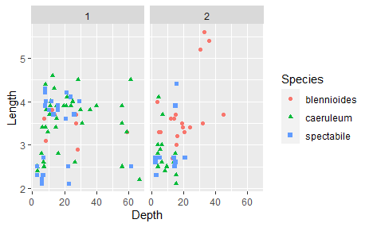

```r
ggplot(darters_tidy)+
  geom_point(mapping=aes(x=Depth,y=Length,color=Species,shape=Species))+
  facet_wrap(~Riffle,ncol=2)
```

```r
####There are fewer blennioides in the first riffle compared to the second.  The first riffle has greater depth overall while the second riffle has long length.
```

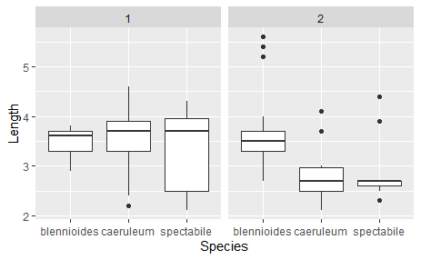

```r
ggplot(data=darters_tidy)+
  geom_boxplot(mapping=aes(x=Species,y=Length))+
  facet_wrap(~Riffle,ncol=2)
```

```r
# riffle 2 has more outliers than riffle 1
```

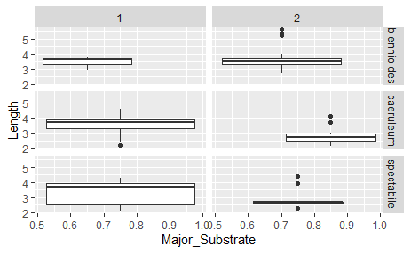

```r
ggplot(data=darters_tidy)+
  geom_boxplot(mapping=aes(x=Major_Substrate,y=Length))+
  facet_grid(Species~Riffle)
```

```r
# this looks right but I do not understand the triangle warning sign?
```

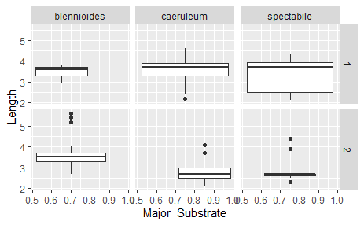

```r
ggplot(data=darters_tidy)+
  geom_boxplot(mapping=aes(x=Major_Substrate,y=Length))+
  facet_grid(Riffle~Species)
```

```r
# This looks nicer as I can compare each species to what riffle it was in.  Riffle 2 again shows more outliers.
```

###THE END